# Camera trap distance sampling workshop

Practical 1 **solution**:  
analysis of point transect songbird data

Workshop development group https://workshops.distancesampling.org (CREEM, Univ of St Andrews)https://www.creem.st-andrews.ac.uk  
2022-03-28

# Simulated data

The code for accessing and checking these data and fitting various models is shown below.

```r
library(Distance)
data("PTExercise")
head(PTExercise, n=3)
```

```
  Region.Label Area Sample.Label Effort object distance  Study.Area
1      Default    0            1      1      1     8.40 PTExercise1
2      Default    0            2      1      2    13.79 PTExercise1
3      Default    0            2      1      3    20.96 PTExercise1
```

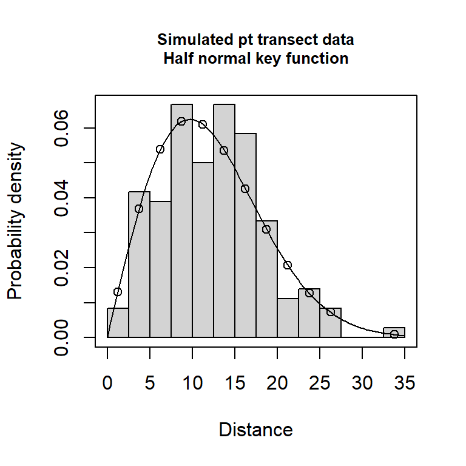

```r
conversion.factor <- convert_units("meter", NULL, "hectare")
bin.cutpoints <- seq(0, 35, by = 2.5)
# Fit half-normal detection function, no truncation, 2.5m cutpoints
PTExercise.hn <- ds(data=PTExercise, transect="point", key="hn", convert_units=conversion.factor,
                    cutpoints=bin.cutpoints)
plot(PTExercise.hn, pdf=TRUE, main="Simulated pt transect data\nHalf normal key function")
```

## Truncation of 20m

```r
bin.cutpoints.20m <- seq(0, 20, by = 2.5)
# Half normal, no adjustments
PTExercise.hn.t20m <- ds(data=PTExercise, transect="point", key="hn",
                    convert_units=conversion.factor, cutpoints=bin.cutpoints.20m)
# Hazard rate, no adjustments
PTExercise.hr.t20m <- ds(data=PTExercise, transect="point", key="hr", truncation=20,
                    convert_units=conversion.factor, cutpoints=bin.cutpoints.20m)
# Uniform, cosine adjustments
PTExercise.uf.cos.t20m <- ds(data=PTExercise, transect="point", key="unif", adjustment="cos",
                             convert_units=conversion.factor, cutpoints=bin.cutpoints.20m)
```

The fit of the detection function to the observed distance data should be assessed using the `gof_ds()` function:

```r
gof_ds(PTExercise.hn.t20m)
```

```
Goodness of fit results for ddf object

Chi-square tests
          [0,2.5] (2.5,5] (5,7.5] (7.5,10] (10,12.5] (12.5,15]
Observed    3.000  15.000  14.000    24.00    18.000    24.000
Expected    4.160  11.846  17.793    21.31    22.251    20.967
Chisquare   0.323   0.840   0.808     0.34     0.812     0.439
          (15,17.5] (17.5,20]   Total
Observed     21.000    12.000 131.000
Expected     18.135    14.538 131.000
Chisquare     0.453     0.443   4.458

P = 0.61501 with 6 degrees of freedom
```

Table 1: Results from simulated point transect data.

| DetectionFunction | Adjustments | Truncation | AIC | Density | D.CV | Lower.CI | Upper.CI |
| --- | --- | --- | --- | --- | --- | --- | --- |
| Half-normal | None | 34.2 | 654.738 | 80.979 | 0.127 | 63.018 | 104.059 |
| Half-normal | None | 20.0 | 525.442 | 71.543 | 0.159 | 52.363 | 97.748 |
| Hazard rate | None | 20.0 | 528.392 | 61.062 | 0.183 | 42.625 | 87.474 |
| Uniform | Cosine | 20.0 | 526.787 | 75.548 | 0.144 | 56.825 | 100.440 |

## Plots of probability density functions to inspect fit

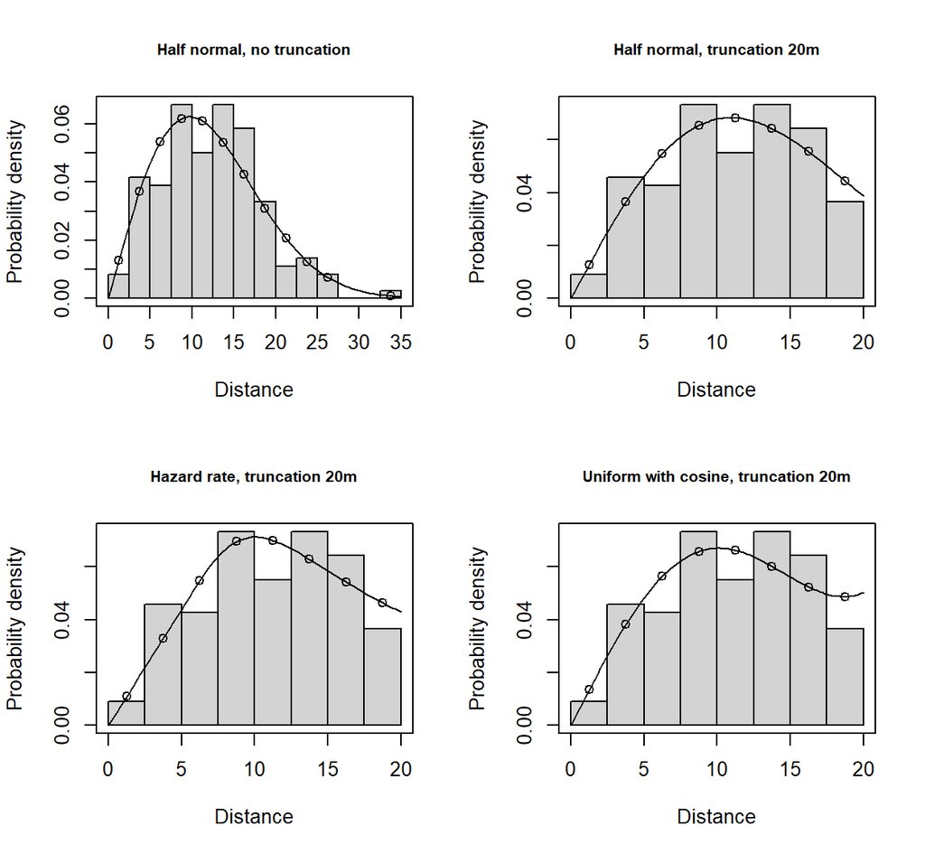

```r
par(mfrow=c(2,2))
plot(PTExercise.hn, main="Half normal, no truncation", pdf=TRUE)
plot(PTExercise.hn.t20m, main="Half normal, truncation 20m", pdf=TRUE)
plot(PTExercise.hr.t20m, main="Hazard rate, truncation 20m", pdf=TRUE)
plot(PTExercise.uf.cos.t20m, main="Uniform with cosine, truncation 20m", pdf=TRUE)
```

We see a fair degree of variability between analyses - reliable analysis of point transect data is more difficult than for line transect data. We see greater loss in precision from truncating data relative to line transect sampling, but if we do not truncate data, different models can give widely differing estimates.

# Wren data (Optional)

First fit the 5 min data. We initially consider a suitable truncation

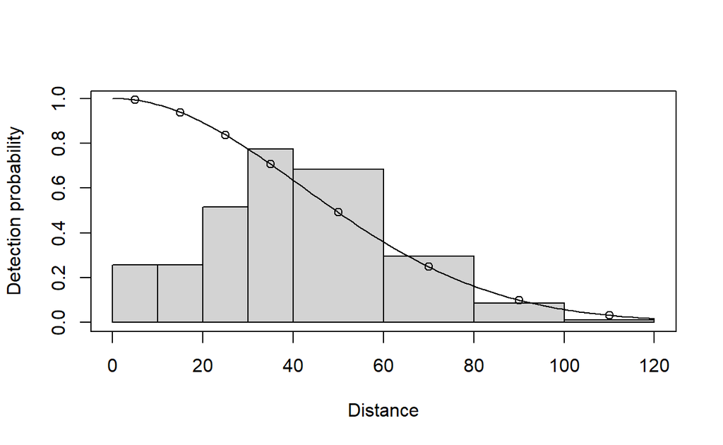

```r
data("wren_5min")
conversion.factor <- convert_units("meter", NULL, "hectare")

#Make an initial fit to look at truncation - half normal with no adjustments
bin.cutpoints <- c(0, 10, 20, 30, 40, 60, 80, 100, 120)
wren5min.hn <- ds(data=wren_5min, key="hn", adjustment = NULL,
                  transect="point", cutpoints=bin.cutpoints,
                  convert_units=conversion.factor)
plot(wren5min.hn)
```

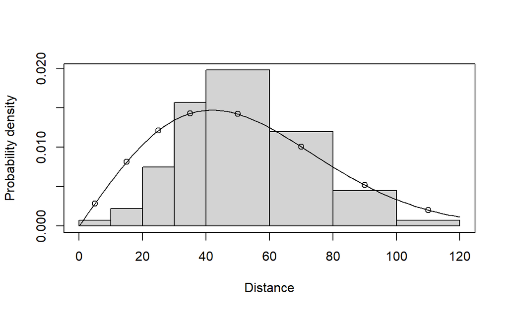

```r
plot(wren5min.hn, pdf = TRUE)
```

100m seems suitable - 80m might also be considered, but involves throwing away a considerable chunk of data.

We now try some candidate models with 100m truncation.

```r
bin.cutpoints.100m <- bin.cutpoints <- c(0, 10, 20, 30, 40, 60, 80, 100)
#Note - code below issues a warning about non-monotonicity -- will want to
# check it out if this becomes the selected model
wren5min.uf.cos.t100 <- ds(data=wren_5min, key="unif", adjustment="cos",
                        transect="point", cutpoints=bin.cutpoints.100m,
                        convert_units=conversion.factor)
#Note - the code below throws an error when trying the second adjustment term
# and so just returns the results for key plus one adjustment
wren5min.hn.herm.t100 <- ds(data=wren_5min, key="hn", adjustment="herm",
                        transect="point", cutpoints=bin.cutpoints.100m,
                        convert_units=conversion.factor)
```

```
Error in integrate(dpdf, lower = x[i, 1], upper = x[i, 2], width = width[i],  :
  the integral is probably divergent
```

```r
wren5min.hr.poly.t100 <- ds(data=wren_5min, key="hr", adjustment="poly",
                        transect="point", cutpoints=bin.cutpoints.100m,
                        convert_units=conversion.factor)
AIC(wren5min.uf.cos.t100, wren5min.hn.herm.t100, wren5min.hr.poly.t100)
```

```
                      df      AIC
wren5min.uf.cos.t100   2 420.4970
wren5min.hn.herm.t100  2 422.8898
wren5min.hr.poly.t100  2 416.6753
```

The hazard rate (with no polynomial adjustments) has the lowest AIC.

Now look at the snapshot data - we use the same truncation although there is actually no requirement to do so.

```r
data("wren_snapshot")
wrensnap.uf.cos.t100 <- ds(data=wren_snapshot, key="unif", adjustment="cos",
                        transect="point", cutpoints=bin.cutpoints.100m,
                        convert_units=conversion.factor)
#Note - the half-normal with Hermite adjustments often throws an error
# and will return the key function without adjustment terms, check # params
wrensnap.hn.herm.t100 <- ds(data=wren_snapshot, key="hn", adjustment="herm",
                        transect="point", cutpoints=bin.cutpoints.100m,
                        convert_units=conversion.factor)
```

```
Error in integrate(dpdf, lower = x[i, 1], upper = x[i, 2], width = width[i],  :
  the integral is probably divergent
Error in integrate(dpdf, lower = x[i, 1], upper = x[i, 2], width = width[i],  :
  the integral is probably divergent
Error in integrate(dpdf, lower = x[i, 1], upper = x[i, 2], width = width[i],  :
  the integral is probably divergent
```

```r
wrensnap.hr.poly.t100 <- ds(data=wren_snapshot, key="hr", adjustment="poly",
                        transect="point", cutpoints=bin.cutpoints.100m,
                        convert_units=conversion.factor)
AIC(wrensnap.uf.cos.t100, wrensnap.hn.herm.t100, wrensnap.hr.poly.t100)
```

```
                      df      AIC
wrensnap.uf.cos.t100   2 368.8596
wrensnap.hn.herm.t100  3 368.9958
wrensnap.hr.poly.t100  2 365.6633
```

The same model as for 5minute data, the hazard rate (with no polynomial adjustments), has the lowest AIC.

## Animal avoidance in Buckland’s winter wren point transects?

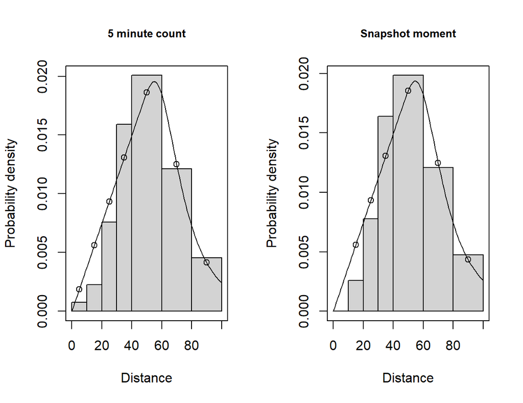

Figure 1: Wren avoidance of observer is evident from surplus of detections 30-60m from point stations.

```r
# Plot detection functions
par(mfrow=c(1,2))
plot(wren5min.hr.poly.t100, main="5 minute count", pdf = TRUE)
plot(wrensnap.hr.poly.t100, main="Snapshot moment", pdf = TRUE)
```

As the detection distance histograms indicate, winter wren showed evidence of observer avoidance, more than other species in the Montrave study. The problem looks more severe when plotting the detection function graph (below), although remember that the histogram bars are scaled in this plot.

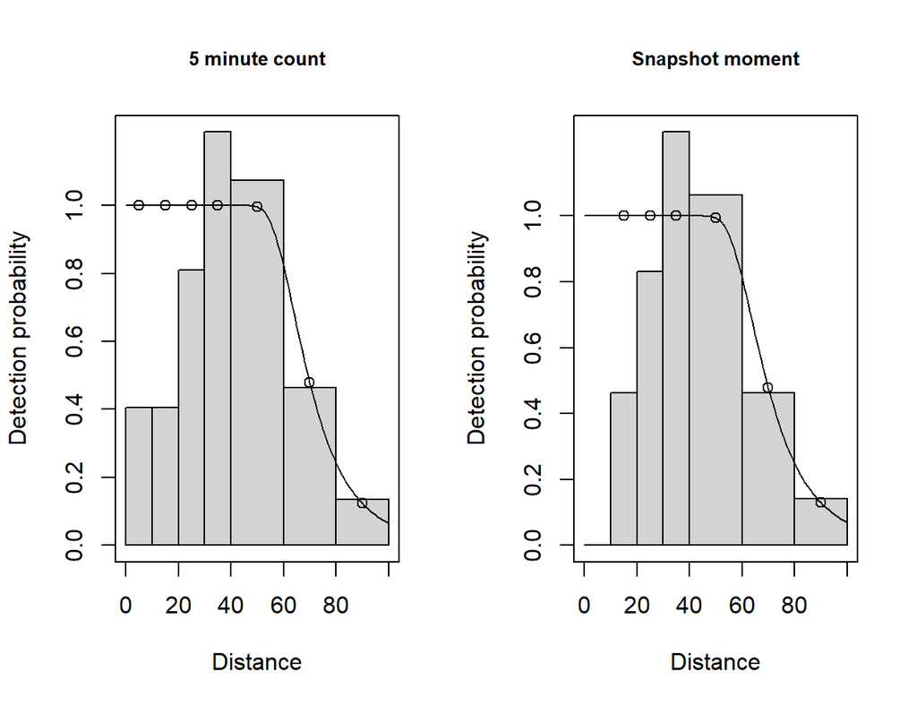

Figure 2: Corresponding detection function plots.

```r
# Plot detection functions
par(mfrow=c(1,2))
plot(wren5min.hr.poly.t100, main="5 minute count")
plot(wrensnap.hr.poly.t100, main="Snapshot moment")
```

```r
gof_ds(wren5min.hr.poly.t100)
```

```
Goodness of fit results for ddf object

Chi-square tests
          [0,10] (10,20] (20,30] (30,40] (40,60] (60,80] (80,100]
Observed   1.000   3.000  10.000  21.000  53.000  32.000   12.000
Expected   2.467   7.401  12.335  17.269  47.544  33.450   11.533
Chisquare  0.872   2.617   0.442   0.806   0.626   0.063    0.019
            Total
Observed  132.000
Expected  132.000
Chisquare   5.446

P = 0.24456 with 4 degrees of freedom
```

```r
gof_ds(wrensnap.hr.poly.t100)
```

```
Goodness of fit results for ddf object

Chi-square tests
          [0,10] (10,20] (20,30] (30,40] (40,60] (60,80] (80,100]
Observed   0.000   3.000   9.000  19.000  46.000  28.000   11.000
Expected   2.163   6.490  10.817  15.144  41.512  29.299   10.574
Chisquare  2.163   1.877   0.305   0.982   0.485   0.058    0.017
            Total
Observed  116.000
Expected  116.000
Chisquare   5.888

P = 0.20771 with 4 degrees of freedom
```

One possible solution would be to combine the 0-40m (or possibly 0-60m) data into one bin – this will mean animals are then counted in their `correct’ bin, although there will then only be 3-4 bins of data to fit the data to, and a very large first bin.

We leave that for a further exercise and compare density estimates between 5-minute and snapshot methods.

## Density estimates

The snapshot method has a (slightly) lower density estimate - in line with what we would expect given that the 5-minute method allows animals to move while the survey is taking place, leading to over-estimation of density (see (Buckland, 2006) for details - although note that he analyzed the exact distance data rather than data in distance bins, and so got slightly different results).

Table 2: Winter wren density estimates from 5 minute counts and snapshot moment.

| Method | Density | Lower.CI | Upper.CI |
| --- | --- | --- | --- |
| Five minute | 1.227 | 0.955 | 1.577 |
| Snapshot | 1.076 | 0.835 | 1.386 |

Buckland, S. T. (2006). Point-transect surveys for songbirds: Robust methodologies. *The Auk*, *123*(2), 345–357. https://doi.org/10.1642/0004-8038(2006)123[345:PSFSRM]2.0.CO;2